# *Train* and *Test* Partitions

Alan T. Arnholt

Last knit on February 19, 2018 at 04:22:07 PM

# 1 Partitions

- Using the `sample()` function (method 1):

```r
> library(mdsr)
> HELP <- na.omit(HELPrct)
> set.seed(123)
> trainIndex1 <- sample(x = c(TRUE, FALSE), size = nrow(HELP), replace = TRUE, prob = c(0.7, 0.3))
> testIndex1 <- (!trainIndex1)
> trainData1 <- HELP[trainIndex1, ]
> testData1 <- HELP[testIndex1, ]
> dim(HELP)
```

```
[1] 117  29
```

```r
> dim(trainData1)
```

```
[1] 82 29
```

```r
> dim(testData1)
```

```
[1] 35 29
```

```r
> # Train Fraction
> dim(trainData1)[1]/dim(HELP)[1]
```

```
[1] 0.7008547
```

```r
> # Test Fraction
> dim(testData1)[1]/dim(HELP)[1]
```

```
[1] 0.2991453
```

- Using the `sample()` function (method 2):

```r
> set.seed(123)
> trainIndex2 <- sample(x = 1:nrow(HELP), size = round(0.70*nrow(HELP), 0), replace = FALSE)
> trainData2 <- HELP[trainIndex2, ]
> testData2 <- HELP[-trainIndex2, ]
> dim(trainData2)
```

```
[1] 82 29
```

```r
> dim(testData2)
```

```
[1] 35 29
```

```r
> # Train Fraction
> dim(trainData2)[1]/dim(HELP)[1]
```

```
[1] 0.7008547
```

```r
> # Test Fraction
> dim(testData2)[1]/dim(HELP)[1]
```

```
[1] 0.2991453
```

- Using `runif()`:

```r
> set.seed(123)
> HELP$Partition <- runif(dim(HELP)[1])
> trainData3 <- subset(HELP, HELP$Partition > 0.3)
> testData3 <- subset(HELP, HELP$Partition <= 0.3)
> dim(trainData3)
```

```
[1] 84 30
```

```r
> dim(testData3)
```

```
[1] 33 30
```

```r
> # Train Fraction
> dim(trainData3)[1]/dim(HELP)[1]
```

```
[1] 0.7179487
```

```r
> # Test Fraction
> dim(testData3)[1]/dim(HELP)[1]
```

```
[1] 0.2820513
```

- Using the `createDataPartition` from the `caret` package:

```r
> library(caret)  # load the caret package
> set.seed(123)
> trainIndex4 <- createDataPartition(y = HELP$homeless, p = .7,
+                                   list = FALSE,
+                                   times = 1)
> trainData4 <- HELP[trainIndex4, ]
> testData4 <- HELP[-trainIndex4, ]
> dim(trainData4)
```

```
[1] 83 30
```

```r
> dim(testData4)
```

```
[1] 34 30
```

```r
> # Train Fraction
> dim(trainData4)[1]/dim(HELP)[1]
```

```
[1] 0.7094017
```

```r
> # Test Fraction
> dim(testData4)[1]/dim(HELP)[1]
```

```
[1] 0.2905983
```

**Note:** When the `y` argument to `createDataPartition` is a factor, the random sampling occurs within each class and should preserve the overall class distribution of the data.

## 1.1 Building a model

In this section, a model is built using the *`training set`* to predict whether a person is `homeless`.

```r
> model.null <- glm(homeless ~ 1, data = trainData4, family = binomial)
> model.full <- glm(homeless ~ ., data = trainData4, family = binomial)
> AICmod <- step(model.null, scope = list(lower = model.null, upper = model.full), direction = "both", data = trainData4)
```

```
Start:  AIC=110.6
homeless ~ 1

               Df Deviance    AIC
+ i1            1   96.888 100.89
+ avg_drinks    1   96.888 100.89
+ i2            1   98.747 102.75
+ max_drinks    1   98.747 102.75
+ female        1  102.302 106.30
+ sex           1  102.302 106.30
+ pss_fr        1  103.184 107.18
+ indtot        1  104.016 108.02
+ e2b           1  105.096 109.10
+ linkstatus    1  105.727 109.73
+ link          1  105.727 109.73
+ substance     2  104.093 110.09
+ g1b           1  106.258 110.26
+ pcs           1  106.570 110.57
+ sexrisk       1  106.580 110.58
<none>             108.605 110.61
+ dayslink      1  106.883 110.88
+ d1            1  106.948 110.95
+ drugrisk      1  107.162 111.16
+ age           1  107.664 111.66
+ treat         1  108.352 112.35
+ anysubstatus  1  108.437 112.44
+ anysub        1  108.437 112.44
+ cesd          1  108.476 112.48
+ satreat       1  108.496 112.50
+ daysanysub    1  108.532 112.53
+ Partition     1  108.533 112.53
+ mcs           1  108.596 112.60
+ id            1  108.605 112.61
+ racegrp       3  108.124 116.12

Step:  AIC=100.89
homeless ~ i1

               Df Deviance     AIC
+ sex           1   89.820  95.820
```

[output cut: 178 more lines]

```
+ Partition     1   77.154  93.154
+ indtot        1   77.235  93.235
+ cesd          1   77.259  93.259
+ daysanysub    1   77.302  93.302
+ treat         1   77.312  93.312
+ id            1   77.355  93.355
+ linkstatus    1   77.375  93.375
+ link          1   77.375  93.375
+ i2            1   77.383  93.383
+ max_drinks    1   77.383  93.383
- g1b           1   81.468  93.468
+ substance     2   77.019  95.019
- sex           1   83.654  95.654
+ racegrp       3   77.212  97.212
- i1            1   88.139 100.139
```

```r
> summary(AICmod)
```

```
Call:
glm(formula = homeless ~ i1 + sex + g1b + pss_fr + dayslink +
    sexrisk, family = binomial, data = trainData4)

Deviance Residuals:
    Min       1Q   Median       3Q      Max
-2.1433  -0.6923  -0.3944   0.7927   1.9780

Coefficients:
             Estimate Std. Error z value Pr(>|z|)
(Intercept)  0.903045   1.240429   0.728   0.4666
i1          -0.057817   0.023137  -2.499   0.0125 *
sexmale     -1.801138   0.764603  -2.356   0.0185 *
g1byes      -1.338143   0.710160  -1.884   0.0595 .
pss_fr       0.159495   0.087981   1.813   0.0699 .
dayslink     0.003429   0.001979   1.733   0.0831 .
sexrisk     -0.161055   0.112725  -1.429   0.1531
---
Signif. codes:  0 '***' 0.001 '**' 0.01 '*' 0.05 '.' 0.1 ' ' 1

(Dispersion parameter for binomial family taken to be 1)

    Null deviance: 108.605  on 82  degrees of freedom
Residual deviance:  77.385  on 76  degrees of freedom
AIC: 91.385

Number of Fisher Scoring iterations: 6
```

### 1.1.1 Pseudo $R^2$

One can think of the pseudo $R^2$ for logistic regression as the analog to $R^2$ used in linear regression. Pseudo $R^2$ measures how much of the deviance is explained by the model, where $R^2$ measures the variability explained by a linear model.

```r
> resid.dev <- summary(AICmod)$deviance
> resid.dev
```

```
[1] 77.38461
```

```r
> null.dev <- summary(AICmod)$null.deviance
> null.dev
```

```
[1] 108.6048
```

```r
> PR2 <- 1 - (resid.dev / null.dev)
> PR2 # Pseudo R squared
```

```
[1] 0.2874657
```

The model only explains 28.75% of the deviance in the training data. This will likely be less for the test data suggesting there are likely other factors that have not been measured that predict homelessness.

```r
> testmod <- glm(homeless ~ i1 + sex + g1b + pss_fr + dayslink + sexrisk, family = binomial, data = testData4)
> resid.dev <- summary(testmod)$deviance
> resid.dev
```

```
[1] 37.53389
```

```r
> null.dev <- summary(testmod)$null.deviance
> null.dev
```

```
[1] 44.14889
```

```r
> PR2 <- 1 - (resid.dev / null.dev)
> PR2 # Pseudo R squared
```

```
[1] 0.1498339
```

```r
> # Note 'type = "response"' gives the predicted probabilities
> PM <- predict(AICmod, newdata = testData4, type = "response")
> pred <- ifelse(PM > 0.5, "homeless", "housed")
> T1 <- table(pred, testData4$homeless)
> T1
```

```
pred       homeless housed
  homeless        6      3
  housed         16      9
```

```r
> Accuracy <- sum(diag(T1))/sum(T1)
> Accuracy
```

```
[1] 0.4411765
```

```r
> # Using caret
> confusionMatrix(data = pred, reference = testData4$homeless)
```

```
Confusion Matrix and Statistics

          Reference
Prediction homeless housed
  homeless        6      3
  housed         16      9

               Accuracy : 0.4412
                 95% CI : (0.2719, 0.6211)
    No Information Rate : 0.6471
    P-Value [Acc > NIR] : 0.995694

                  Kappa : 0.0182
 Mcnemar's Test P-Value : 0.005905

            Sensitivity : 0.2727
            Specificity : 0.7500
         Pos Pred Value : 0.6667
         Neg Pred Value : 0.3600
             Prevalence : 0.6471
         Detection Rate : 0.1765
   Detection Prevalence : 0.2647
      Balanced Accuracy : 0.5114

       'Positive' Class : homeless
```

See [Confusion Matrix](https://en.wikipedia.org/wiki/Confusion_matrix) on Wikipedia.

## 1.2 ROC

An ROC curve is a really useful shortcut for summarizing the performance of a classifier over all possible thresholds. This saves one a lot of tedious work computing class predictions for many different thresholds and examining the confusion matrix for each threshold.

### 1.2.1 AUC (Area Under the Curve)

- Single-number summary of model accuracy
- Summarizes performance accross all thresholds
- Rank different models within the same dataset

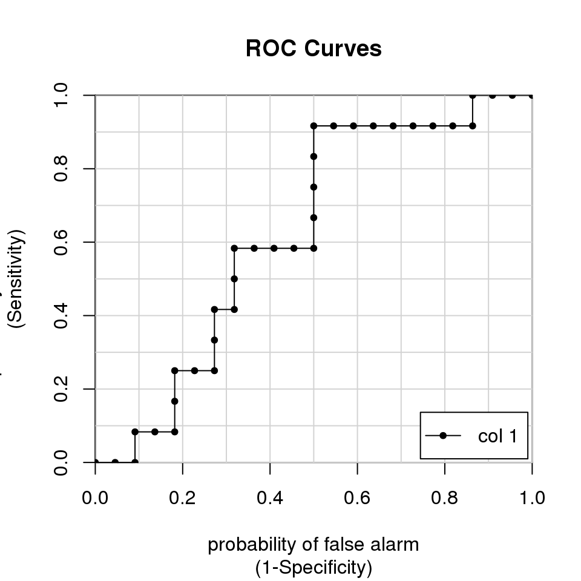

```
                     [,1]
homeless vs. housed 0.625
```

```r
> library(caTools)
> colAUC(PM, testData4$homeless, plotROC = TRUE)
```

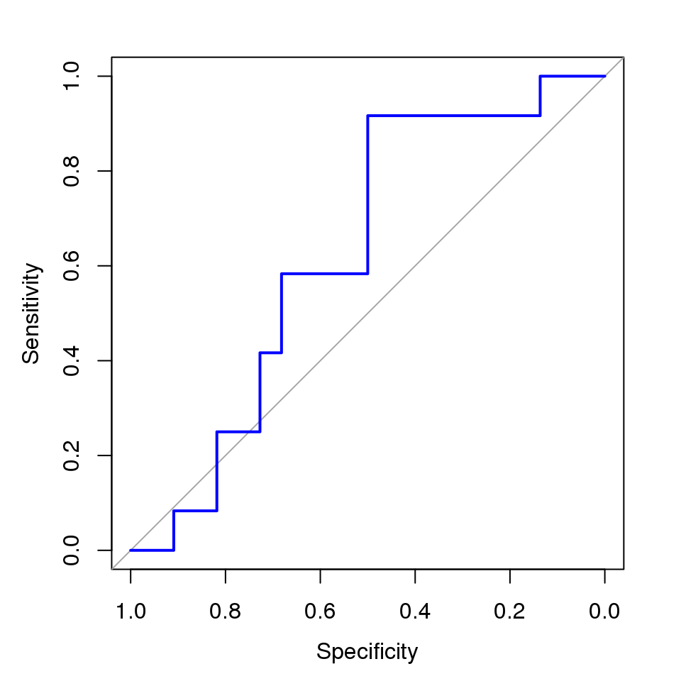

```r
> library(pROC)
> ROC <- roc(testData4$homeless, PM) # Note the order is switched here
> plot(ROC, col = "blue")
```

```r
> auc(ROC)
```

```
Area under the curve: 0.625
```

An AUC of 0.5 is no better than random guessing, an AUC of 1.0 is a perfectly predictive model, and an AUC of 0.0 is perfectly anti-predictive (which rarely happens). One can use the `trainControl()` function in `caret` to use AUC (instead of acccuracy), to tune the parameters of your models. The `twoClassSummary()` convenience function allows one to do this easily.

When using `twoClassSummary()`, be sure to always include the argument `classProbs = TRUE` or your model will throw an error! (You cannot calculate AUC with just class predictions. You need to have class probabilities as well.)

```r
> # Create trainControl object: myControl
> myControl <- trainControl(
+   # method = "cv",
+   # number = 10,
+   summaryFunction = twoClassSummary,
+   classProbs = TRUE, # IMPORTANT!
+   verbose = FALSE
+ )
> #
> # Train glm with custom trainControl: model
> model <- train(homeless ~ ., data = trainData4, method = "glmStepAIC",
+                trControl = myControl)
```

```
Start:  AIC=124.46
.outcome ~ age + anysubstatus + anysubyes + cesd + d1 + daysanysub +
    dayslink + drugrisk + e2b + female + sexmale + g1byes + i1 +
    i2 + id + indtot + linkstatus + linkyes + mcs + pcs + pss_fr +
    racegrphispanic + racegrpother + racegrpwhite + satreatyes +
    sexrisk + substancecocaine + substanceheroin + treatyes +
    avg_drinks + max_drinks + Partition


Step:  AIC=124.46
.outcome ~ age + anysubstatus + anysubyes + cesd + d1 + daysanysub +
    dayslink + drugrisk + e2b + female + sexmale + g1byes + i1 +
    i2 + id + indtot + linkstatus + linkyes + mcs + pcs + pss_fr +
    racegrphispanic + racegrpother + racegrpwhite + satreatyes +
    sexrisk + substancecocaine + substanceheroin + treatyes +
    avg_drinks + Partition


Step:  AIC=124.46
.outcome ~ age + anysubstatus + anysubyes + cesd + d1 + daysanysub +
    dayslink + drugrisk + e2b + female + sexmale + g1byes + i1 +
    i2 + id + indtot + linkstatus + linkyes + mcs + pcs + pss_fr +
    racegrphispanic + racegrpother + racegrpwhite + satreatyes +
    sexrisk + substancecocaine + substanceheroin + treatyes +
    Partition


Step:  AIC=124.46
.outcome ~ age + anysubstatus + anysubyes + cesd + d1 + daysanysub +
    dayslink + drugrisk + e2b + female + sexmale + g1byes + i1 +
    i2 + id + indtot + linkstatus + mcs + pcs + pss_fr + racegrphispanic +
    racegrpother + racegrpwhite + satreatyes + sexrisk + substancecocaine +
    substanceheroin + treatyes + Partition


Step:  AIC=124.46
.outcome ~ age + anysubstatus + anysubyes + cesd + d1 + daysanysub +
    dayslink + drugrisk + e2b + female + g1byes + i1 + i2 + id +
    indtot + linkstatus + mcs + pcs + pss_fr + racegrphispanic +
    racegrpother + racegrpwhite + satreatyes + sexrisk + substancecocaine +
```

[output cut: 532 more lines]

```
- pss_fr    1   79.783  93.783
- female    1   82.121  96.121
- i1        1   86.744 100.744

Step:  AIC=91.38
.outcome ~ dayslink + female + g1byes + i1 + pss_fr + sexrisk

           Df Deviance     AIC
<none>          77.385  91.385
- sexrisk   1   79.519  91.519
- dayslink  1   80.603  92.603
- pss_fr    1   80.916  92.916
- g1byes    1   81.468  93.468
- female    1   83.654  95.654
- i1        1   88.139 100.139
```

```r
> # Print model to console
> model
```

```
Generalized Linear Model with Stepwise Feature Selection

83 samples
29 predictors
 2 classes: 'homeless', 'housed'

No pre-processing
Resampling: Bootstrapped (25 reps)
Summary of sample sizes: 83, 83, 83, 83, 83, 83, ...
Resampling results:

  ROC        Sens       Spec
  0.5307497  0.5851495  0.4547207
```

```r
> summary(model)
```

```
Call:
NULL

Deviance Residuals:
    Min       1Q   Median       3Q      Max
-2.1433  -0.6923  -0.3944   0.7927   1.9780

Coefficients:
             Estimate Std. Error z value Pr(>|z|)
(Intercept) -0.898093   0.951086  -0.944   0.3450
dayslink     0.003429   0.001979   1.733   0.0831 .
female       1.801138   0.764603   2.356   0.0185 *
g1byes      -1.338143   0.710160  -1.884   0.0595 .
i1          -0.057817   0.023137  -2.499   0.0125 *
pss_fr       0.159495   0.087981   1.813   0.0699 .
sexrisk     -0.161055   0.112725  -1.429   0.1531
---
Signif. codes:  0 '***' 0.001 '**' 0.01 '*' 0.05 '.' 0.1 ' ' 1

(Dispersion parameter for binomial family taken to be 1)

    Null deviance: 108.605  on 82  degrees of freedom
Residual deviance:  77.385  on 76  degrees of freedom
AIC: 91.385

Number of Fisher Scoring iterations: 6
```

## 1.3 GLMNET

- `alpha = 0` $\rightarrow$ ridge
- `alpha = 1` $\rightarrow$ lasso

```r
> set.seed(234)
> # Create custom trainControl: myControl
> myControl <- trainControl(
+   method = "cv", number = 10,
+   summaryFunction = twoClassSummary,
+   classProbs = TRUE, # IMPORTANT!
+   verboseIter = TRUE
+ )
> # Train glmnet with custom trainControl and tuning: model
> model <- train(
+   homeless ~ ., data = trainData4,
+   tuneGrid = expand.grid(alpha  = 0:1, lambda = seq(0.0001, 4, length = 20)),
+   method = "glmnet",
+   trControl = myControl
+ )
> # Print model to console
> model
```

```
glmnet

83 samples
29 predictors
 2 classes: 'homeless', 'housed'

No pre-processing
Resampling: Cross-Validated (10 fold)
Summary of sample sizes: 74, 75, 75, 75, 75, 75, ...
Resampling results across tuning parameters:

  alpha  lambda     ROC        Sens       Spec
  0      0.0001000  0.5766667  0.7166667  0.40000000
  0      0.2106211  0.6188889  0.7966667  0.33333333
  0      0.4211421  0.6455556  0.8466667  0.30000000
```

[output cut: 40 more lines]

```r
> # Print maximum ROC statistic
> max(model[["results"]][["ROC"]])
```

```
[1] 0.7033333
```

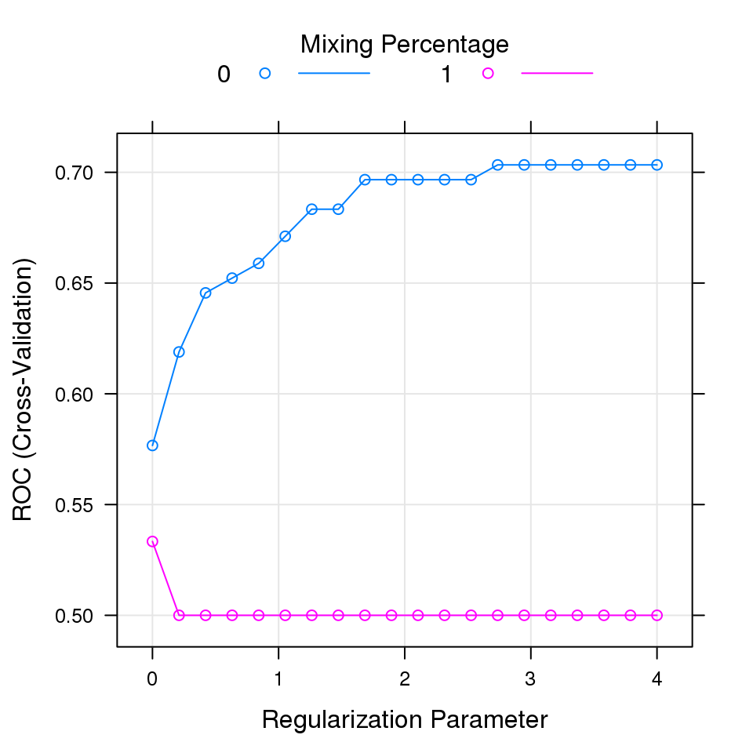

```r
> plot(model)
```

### 1.3.1 Imputation

- Median (`medianImpute`)
- knn (`knnImpute`)
- bagged tree model (`bagImpute`)

```r
> # Create custom trainControl: myControl
> myControl <- trainControl(
+   method = "cv", number = 10,
+   summaryFunction = twoClassSummary,
+   classProbs = TRUE, # IMPORTANT!
+   verboseIter = TRUE
+ )
>
> # Train glmnet with custom trainControl and tuning: model
>
> model <- train(
+   homeless ~ ., data = HELPrct,
+   tuneGrid = expand.grid(alpha  = 0:1, lambda = seq(0.0001, 100, length = 20)),
+   method = "glmnet",
+   metric = "ROC",
+   trControl = myControl,
+   preProcess = c("knnImpute"),
+   na.action = na.pass
+ )
> # Print model to console
> model
```

```
glmnet

453 samples
 28 predictor
  2 classes: 'homeless', 'housed'

Pre-processing: nearest neighbor imputation (31), centered (31),
 scaled (31)
Resampling: Cross-Validated (10 fold)
Summary of sample sizes: 408, 407, 407, 408, 408, 409, ...
Resampling results across tuning parameters:

  alpha  lambda      ROC        Sens         Spec
  0        0.000100  0.6509484  0.482142857  0.6888333
  0        5.263253  0.6622321  0.104761905  0.9631667
```

[output cut: 41 more lines]

```r
> # Print maximum ROC statistic
> max(model[["results"]][["ROC"]])
```

```
[1] 0.6625456
```

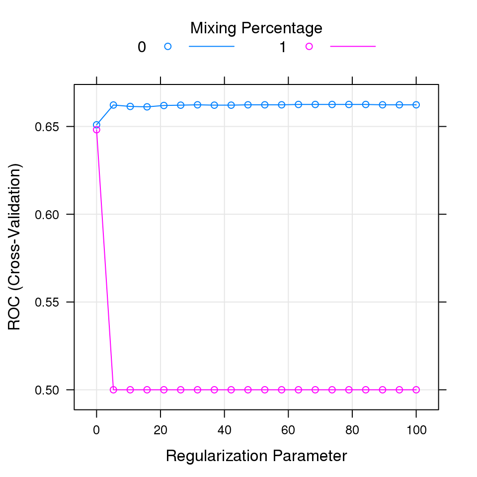

```r
> plot(model)
```

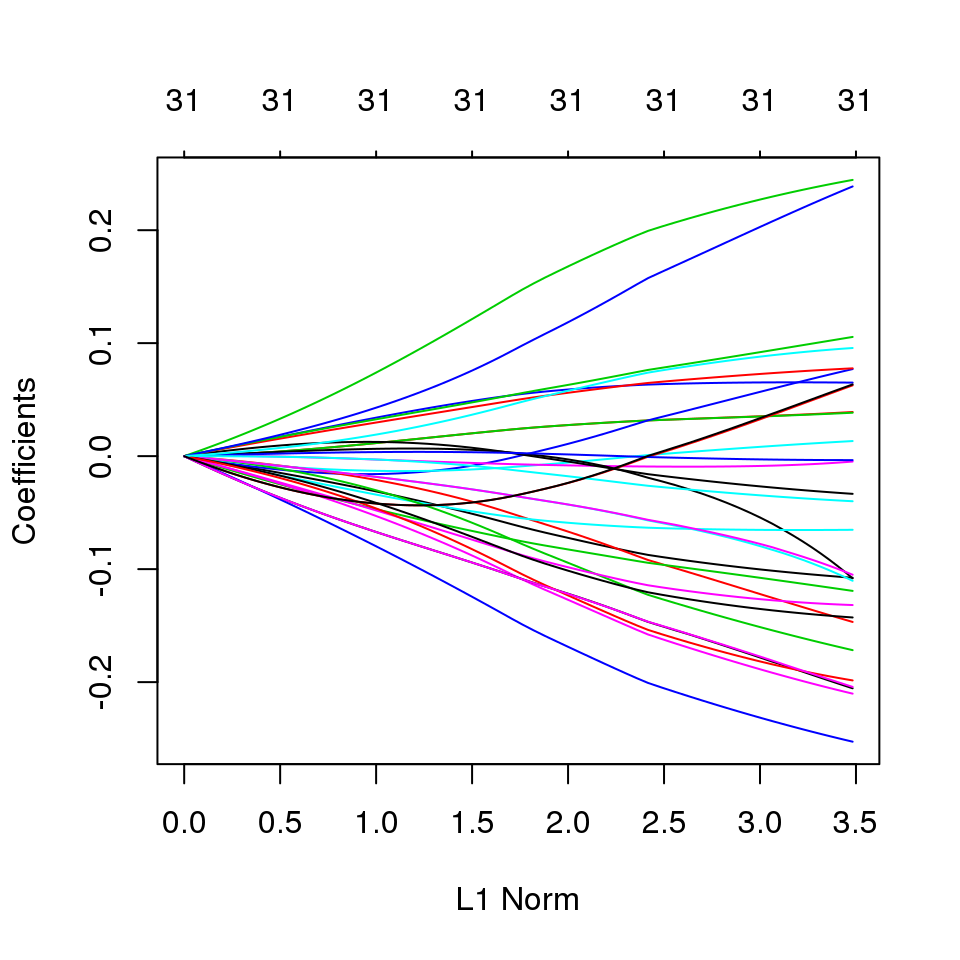

```r
> plot(model$finalModel)
```

```r
> # getting coefficients
> coef(model$finalModel, model$bestTune$lambda)
```

```
32 x 1 sparse Matrix of class "dgCMatrix"
                             1
(Intercept)       1.547866e-01
age              -5.052402e-04
anysubstatus      7.175112e-05
anysubyes         7.173183e-05
cesd             -5.094988e-04
d1               -3.875314e-04
daysanysub        4.354365e-05
dayslink          1.266469e-04
drugrisk         -2.331586e-04
e2b              -9.065190e-04
female            5.748621e-04
sexmale          -5.747121e-04
g1byes           -7.787904e-04
i1               -1.392394e-03
i2               -1.147066e-03
id               -2.852674e-04
indtot           -1.268734e-03
linkstatus       -2.771621e-04
linkyes          -2.770897e-04
mcs               3.990764e-04
pcs               5.605130e-04
pss_fr            1.019032e-03
racegrphispanic   8.851136e-05
racegrpother     -9.493057e-07
racegrpwhite     -7.793520e-04
satreatyes       -4.924555e-04
sexrisk          -5.681747e-04
substancecocaine  6.125276e-04
substanceheroin   5.974870e-04
treatyes          1.996529e-04
avg_drinks       -1.391529e-03
max_drinks       -1.146225e-03
```

## 1.4 Working with ISLR data

### 1.4.1 First Ridge

```r
> library(ISLR)
> library(caret)
> Hitters <- na.omit(Hitters)
> summary(Hitters)
```

```
     AtBat            Hits           HmRun            Runs
 Min.   : 19.0   Min.   :  1.0   Min.   : 0.00   Min.   :  0.00
 1st Qu.:282.5   1st Qu.: 71.5   1st Qu.: 5.00   1st Qu.: 33.50
 Median :413.0   Median :103.0   Median : 9.00   Median : 52.00
 Mean   :403.6   Mean   :107.8   Mean   :11.62   Mean   : 54.75
 3rd Qu.:526.0   3rd Qu.:141.5   3rd Qu.:18.00   3rd Qu.: 73.00
 Max.   :687.0   Max.   :238.0   Max.   :40.00   Max.   :130.00
      RBI             Walks            Years            CAtBat
 Min.   :  0.00   Min.   :  0.00   Min.   : 1.000   Min.   :   19.0
 1st Qu.: 30.00   1st Qu.: 23.00   1st Qu.: 4.000   1st Qu.:  842.5
 Median : 47.00   Median : 37.00   Median : 6.000   Median : 1931.0
 Mean   : 51.49   Mean   : 41.11   Mean   : 7.312   Mean   : 2657.5
 3rd Qu.: 71.00   3rd Qu.: 57.00   3rd Qu.:10.000   3rd Qu.: 3890.5
 Max.   :121.00   Max.   :105.00   Max.   :24.000   Max.   :14053.0
     CHits            CHmRun           CRuns             CRBI
 Min.   :   4.0   Min.   :  0.00   Min.   :   2.0   Min.   :   3.0
 1st Qu.: 212.0   1st Qu.: 15.00   1st Qu.: 105.5   1st Qu.:  95.0
 Median : 516.0   Median : 40.00   Median : 250.0   Median : 230.0
 Mean   : 722.2   Mean   : 69.24   Mean   : 361.2   Mean   : 330.4
 3rd Qu.:1054.0   3rd Qu.: 92.50   3rd Qu.: 497.5   3rd Qu.: 424.5
 Max.   :4256.0   Max.   :548.00   Max.   :2165.0   Max.   :1659.0
     CWalks       League  Division    PutOuts          Assists
 Min.   :   1.0   A:139   E:129    Min.   :   0.0   Min.   :  0.0
 1st Qu.:  71.0   N:124   W:134    1st Qu.: 113.5   1st Qu.:  8.0
 Median : 174.0                    Median : 224.0   Median : 45.0
 Mean   : 260.3                    Mean   : 290.7   Mean   :118.8
 3rd Qu.: 328.5                    3rd Qu.: 322.5   3rd Qu.:192.0
 Max.   :1566.0                    Max.   :1377.0   Max.   :492.0
     Errors           Salary       NewLeague
 Min.   : 0.000   Min.   :  67.5   A:141
 1st Qu.: 3.000   1st Qu.: 190.0   N:122
 Median : 7.000   Median : 425.0
 Mean   : 8.593   Mean   : 535.9
 3rd Qu.:13.000   3rd Qu.: 750.0
 Max.   :32.000   Max.   :2460.0
```

```r
> dim(Hitters)
```

```
[1] 263  20
```

```r
> set.seed(1)
> myControl <- trainControl(
+   method = "cv",
+   number = 10
+ )
> hit.model <- train(
+   Salary ~ ., data = Hitters,
+   tuneGrid = expand.grid(alpha = 0, lambda = 10^seq(3, -2, length = 100)),
+   method = "glmnet",
+   trControl = myControl
+ )
> hit.model
```

```
glmnet

263 samples
 19 predictor

No pre-processing
Resampling: Cross-Validated (10 fold)
Summary of sample sizes: 235, 237, 238, 236, 237, 237, ...
Resampling results across tuning parameters:

  lambda        RMSE      Rsquared   MAE
  1.000000e-02  326.1370  0.4702243  232.7176
  1.123324e-02  326.1370  0.4702243  232.7176
  1.261857e-02  326.1370  0.4702243  232.7176
  1.417474e-02  326.1370  0.4702243  232.7176
  1.592283e-02  326.1370  0.4702243  232.7176
  1.788650e-02  326.1370  0.4702243  232.7176
  2.009233e-02  326.1370  0.4702243  232.7176
  2.257020e-02  326.1370  0.4702243  232.7176
  2.535364e-02  326.1370  0.4702243  232.7176
  2.848036e-02  326.1370  0.4702243  232.7176
  3.199267e-02  326.1370  0.4702243  232.7176
  3.593814e-02  326.1370  0.4702243  232.7176
  4.037017e-02  326.1370  0.4702243  232.7176
  4.534879e-02  326.1370  0.4702243  232.7176
  5.094138e-02  326.1370  0.4702243  232.7176
  5.722368e-02  326.1370  0.4702243  232.7176
  6.428073e-02  326.1370  0.4702243  232.7176
  7.220809e-02  326.1370  0.4702243  232.7176
  8.111308e-02  326.1370  0.4702243  232.7176
  9.111628e-02  326.1370  0.4702243  232.7176
  1.023531e-01  326.1370  0.4702243  232.7176
  1.149757e-01  326.1370  0.4702243  232.7176
  1.291550e-01  326.1370  0.4702243  232.7176
  1.450829e-01  326.1370  0.4702243  232.7176
  1.629751e-01  326.1370  0.4702243  232.7176
  1.830738e-01  326.1370  0.4702243  232.7176
  2.056512e-01  326.1370  0.4702243  232.7176
  2.310130e-01  326.1370  0.4702243  232.7176
  2.595024e-01  326.1370  0.4702243  232.7176
```

[output cut: 60 more lines]

```
  3.125716e+02  327.8324  0.4725723  229.4141
  3.511192e+02  328.1865  0.4727470  229.7859
  3.944206e+02  328.6129  0.4728922  230.3146
  4.430621e+02  329.1222  0.4729971  230.9594
  4.977024e+02  329.7271  0.4730507  231.7418
  5.590810e+02  330.4383  0.4730559  232.5937
  6.280291e+02  331.2665  0.4730212  233.5686
  7.054802e+02  332.2254  0.4729347  234.6652
  7.924829e+02  333.3302  0.4727990  235.9015
  8.902151e+02  334.5908  0.4726197  237.4501
  1.000000e+03  336.0245  0.4723993  239.3706

Tuning parameter 'alpha' was held constant at a value of 0
RMSE was used to select the optimal model using the smallest value.
The final values used for the model were alpha = 0 and lambda = 21.54435.
```

```r
> coef(hit.model$finalModel, s = 11498)
```

```
20 x 1 sparse Matrix of class "dgCMatrix"
                        1
(Intercept) 407.205936774
AtBat         0.037003083
Hits          0.138357552
HmRun         0.525195508
Runs          0.230978290
RBI           0.240114775
Walks         0.289971555
Years         1.108832399
CAtBat        0.003135215
CHits         0.011666684
CHmRun        0.087642789
CRuns         0.023406258
CRBI          0.024165723
CWalks        0.025042117
LeagueN       0.086629234
DivisionW    -6.225431332
PutOuts       0.016506596
Assists       0.002616335
Errors       -0.020564158
NewLeagueN    0.302922899
```

```r
> coef(hit.model$finalModel, s = 705)
```

```
20 x 1 sparse Matrix of class "dgCMatrix"
                       1
(Intercept)  54.39019010
AtBat         0.11199103
Hits          0.65618308
HmRun         1.17557058
Runs          0.93745780
RBI           0.84682838
Walks         1.32044897
Years         2.58210272
CAtBat        0.01082850
CHits         0.04681147
CHmRun        0.33843942
CRuns         0.09372165
CRBI          0.09788930
CWalks        0.07179422
LeagueN      13.69631793
DivisionW   -54.71693537
PutOuts       0.11864655
Assists       0.01610360
Errors       -0.70439782
NewLeagueN    8.60936304
```

```r
> coef(hit.model$finalModel, s = 50)
```

```
20 x 1 sparse Matrix of class "dgCMatrix"
                        1
(Intercept)  4.821654e+01
AtBat       -3.538650e-01
Hits         1.953167e+00
HmRun       -1.285127e+00
Runs         1.156329e+00
RBI          8.087771e-01
Walks        2.709765e+00
Years       -6.202919e+00
CAtBat       6.085854e-03
CHits        1.070832e-01
CHmRun       6.290984e-01
CRuns        2.172926e-01
CRBI         2.152888e-01
CWalks      -1.488961e-01
LeagueN      4.586262e+01
DivisionW   -1.182304e+02
PutOuts      2.501647e-01
Assists      1.208491e-01
Errors      -3.277073e+00
NewLeagueN  -9.423459e+00
```

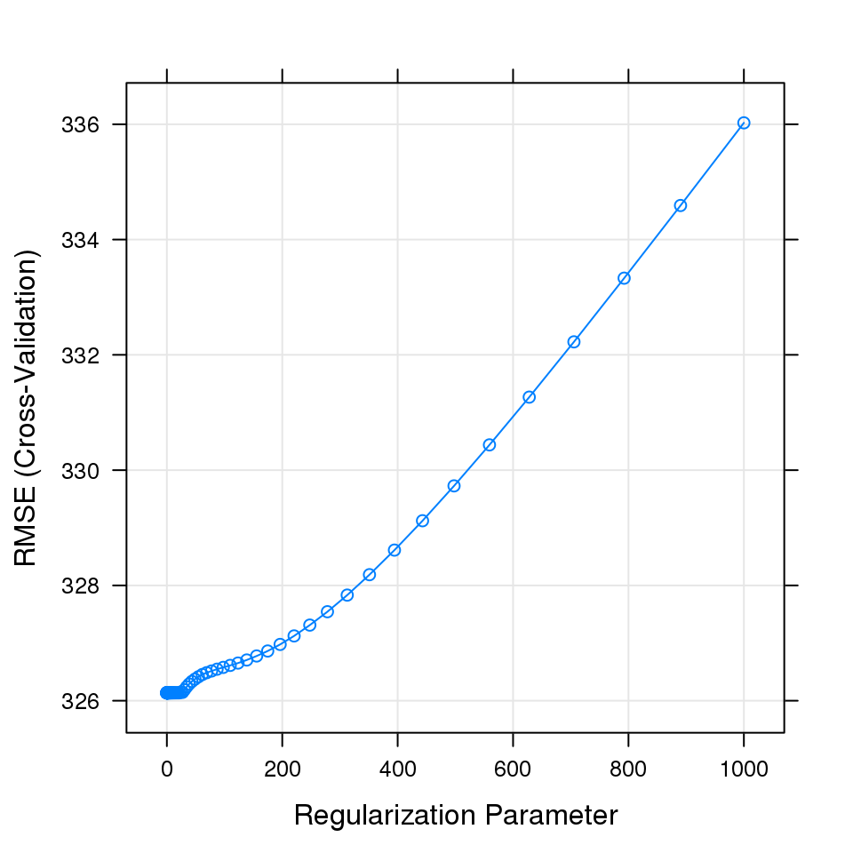

```r
> plot(hit.model)
```

```r
> coef(hit.model$finalModel, hit.model$bestTune$lambda)
```

```
20 x 1 sparse Matrix of class "dgCMatrix"
                        1
(Intercept)  8.112693e+01
AtBat       -6.815959e-01
Hits         2.772312e+00
HmRun       -1.365680e+00
Runs         1.014826e+00
RBI          7.130224e-01
Walks        3.378558e+00
Years       -9.066800e+00
CAtBat      -1.199478e-03
CHits        1.361029e-01
CHmRun       6.979958e-01
CRuns        2.958896e-01
CRBI         2.570711e-01
CWalks      -2.789666e-01
LeagueN      5.321272e+01
DivisionW   -1.228345e+02
PutOuts      2.638876e-01
Assists      1.698796e-01
Errors      -3.685645e+00
NewLeagueN  -1.810510e+01
```

```r
> hit.model$bestTune$lambda
```

```
[1] 21.54435
```

Following ISLR, the data set is split into a training and a test set in order to estimate the error of each method.

```r
> library(caret)
> set.seed(52)
> trainIndex <- createDataPartition(y = Hitters$Salary, p = 0.5,
+                                 list = FALSE,
+                                 times = 1)
> HittersTrain <- Hitters[trainIndex, ]
> HittersTest <- Hitters[-trainIndex, ]
> dim(HittersTrain)
```

```
[1] 133  20
```

```r
> dim(HittersTest)
```

```
[1] 130  20
```

```r
> myControl <- trainControl(
+   method = "repeatedcv",
+   repeats = 3
+ )
> hit.modelT <- train(
+   Salary ~ ., data = HittersTrain,
+   tuneGrid = expand.grid(alpha = 0, lambda = 10^seq(3, -2, length = 100)),
+   method = "glmnet",
+   trControl = myControl
+ )
> hit.modelT
```

```
glmnet

133 samples
 19 predictor

No pre-processing
Resampling: Cross-Validated (10 fold, repeated 3 times)
Summary of sample sizes: 121, 119, 118, 119, 120, 119, ...
Resampling results across tuning parameters:

  lambda        RMSE      Rsquared   MAE
  1.000000e-02  321.2987  0.5202461  238.3084
  1.123324e-02  321.2987  0.5202461  238.3084
  1.261857e-02  321.2987  0.5202461  238.3084
  1.417474e-02  321.2987  0.5202461  238.3084
  1.592283e-02  321.2987  0.5202461  238.3084
  1.788650e-02  321.2987  0.5202461  238.3084
  2.009233e-02  321.2987  0.5202461  238.3084
  2.257020e-02  321.2987  0.5202461  238.3084
  2.535364e-02  321.2987  0.5202461  238.3084
  2.848036e-02  321.2987  0.5202461  238.3084
  3.199267e-02  321.2987  0.5202461  238.3084
  3.593814e-02  321.2987  0.5202461  238.3084
  4.037017e-02  321.2987  0.5202461  238.3084
  4.534879e-02  321.2987  0.5202461  238.3084
  5.094138e-02  321.2987  0.5202461  238.3084
  5.722368e-02  321.2987  0.5202461  238.3084
  6.428073e-02  321.2987  0.5202461  238.3084
  7.220809e-02  321.2987  0.5202461  238.3084
  8.111308e-02  321.2987  0.5202461  238.3084
  9.111628e-02  321.2987  0.5202461  238.3084
  1.023531e-01  321.2987  0.5202461  238.3084
  1.149757e-01  321.2987  0.5202461  238.3084
  1.291550e-01  321.2987  0.5202461  238.3084
  1.450829e-01  321.2987  0.5202461  238.3084
  1.629751e-01  321.2987  0.5202461  238.3084
  1.830738e-01  321.2987  0.5202461  238.3084
  2.056512e-01  321.2987  0.5202461  238.3084
  2.310130e-01  321.2987  0.5202461  238.3084
  2.595024e-01  321.2987  0.5202461  238.3084
```

[output cut: 60 more lines]

```
  3.125716e+02  311.5661  0.5413587  228.1176
  3.511192e+02  311.6207  0.5423086  227.7972
  3.944206e+02  311.7973  0.5431752  227.6065
  4.430621e+02  312.1111  0.5439354  227.5245
  4.977024e+02  312.5786  0.5445833  227.6521
  5.590810e+02  313.2115  0.5451243  227.9577
  6.280291e+02  314.0241  0.5455579  228.3820
  7.054802e+02  315.0340  0.5458633  229.1220
  7.924829e+02  316.2548  0.5460531  230.1591
  8.902151e+02  317.7011  0.5461314  231.4492
  1.000000e+03  319.3866  0.5461103  232.9972

Tuning parameter 'alpha' was held constant at a value of 0
RMSE was used to select the optimal model using the smallest value.
The final values used for the model were alpha = 0 and lambda = 312.5716.
```

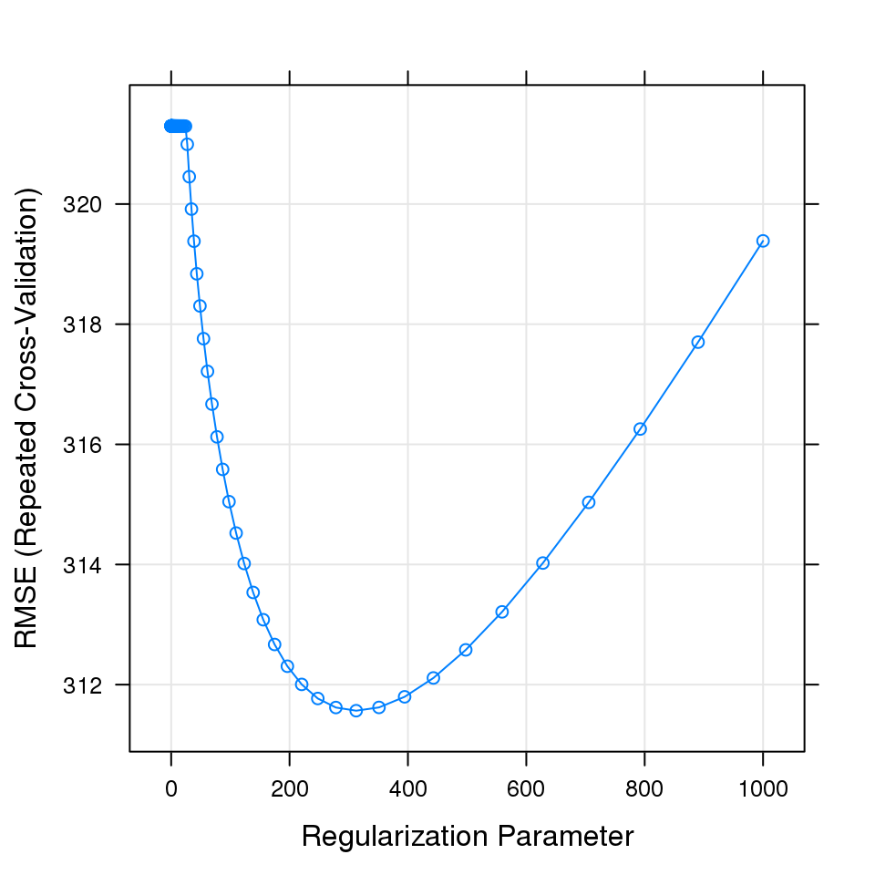

```r
> plot(hit.modelT)
```

```r
> coef(hit.modelT$finalModel, hit.modelT$bestTune$lambda)
```

```
20 x 1 sparse Matrix of class "dgCMatrix"
                        1
(Intercept) -1.247903e+02
AtBat        1.459814e-01
Hits         1.081891e+00
HmRun        1.698469e+00
Runs         1.460525e+00
RBI          1.253918e+00
Walks        1.812634e+00
Years        3.240116e+00
CAtBat       1.105952e-02
CHits        5.240973e-02
CHmRun       1.439892e-01
CRuns        1.036923e-01
CRBI         8.809254e-02
CWalks       3.357095e-02
LeagueN      3.943543e+01
DivisionW   -9.517743e+01
PutOuts      2.307162e-01
Assists     -6.219518e-03
Errors       4.962977e-01
NewLeagueN   1.523493e+01
```

```r
> # Test RMSE error
> preds <- predict(hit.modelT, HittersTest)
> TestRMSE1 <- sqrt(mean((HittersTest$Salary - preds)^2))
> TestRMSE1
```

```
[1] 365.7261
```

### 1.4.2 Next Lasso

```r
> set.seed(14)
> myControl <- trainControl(
+   method = "repeatedcv",
+   repeats = 3
+ )
> hit.modelT1 <- train(
+   Salary ~ ., data = HittersTrain,
+   tuneGrid = expand.grid(alpha = 1, lambda = 10^seq(3, -2, length = 100)),
+   method = "glmnet",
+   trControl = myControl
+ )
> hit.modelT1
```

```
glmnet

133 samples
 19 predictor

No pre-processing
Resampling: Cross-Validated (10 fold, repeated 3 times)
Summary of sample sizes: 120, 120, 119, 120, 120, 118, ...
Resampling results across tuning parameters:

  lambda        RMSE      Rsquared   MAE
  1.000000e-02  344.9567  0.5317168  251.2481
  1.123324e-02  344.9567  0.5317168  251.2481
  1.261857e-02  344.9567  0.5317168  251.2481
  1.417474e-02  344.9567  0.5317168  251.2481
  1.592283e-02  344.9567  0.5317168  251.2481
  1.788650e-02  344.9567  0.5317168  251.2481
  2.009233e-02  344.9567  0.5317168  251.2481
  2.257020e-02  344.9567  0.5317168  251.2481
  2.535364e-02  344.9484  0.5317445  251.2406
  2.848036e-02  344.9330  0.5317989  251.2263
  3.199267e-02  344.9155  0.5318604  251.2086
  3.593814e-02  344.8958  0.5319292  251.1888
  4.037017e-02  344.8740  0.5320059  251.1666
  4.534879e-02  344.8490  0.5320934  251.1410
  5.094138e-02  344.8214  0.5321900  251.1124
  5.722368e-02  344.7907  0.5322978  251.0802
  6.428073e-02  344.7565  0.5324185  251.0441
  7.220809e-02  344.7144  0.5325631  251.0005
  8.111308e-02  344.6602  0.5327433  250.9457
  9.111628e-02  344.6019  0.5329387  250.8865
  1.023531e-01  344.5408  0.5331493  250.8245
  1.149757e-01  344.4645  0.5334218  250.7559
  1.291550e-01  344.4250  0.5337040  250.6943
  1.450829e-01  344.3778  0.5339582  250.6183
  1.629751e-01  344.3072  0.5342806  250.5108
  1.830738e-01  344.2157  0.5347082  250.4100
  2.056512e-01  344.1290  0.5351863  250.3028
  2.310130e-01  344.0172  0.5356807  250.1652
  2.595024e-01  343.8899  0.5363539  250.0190
```

[output cut: 60 more lines]

```
  3.125716e+02  437.4395        NaN  348.8411
  3.511192e+02  437.4395        NaN  348.8411
  3.944206e+02  437.4395        NaN  348.8411
  4.430621e+02  437.4395        NaN  348.8411
  4.977024e+02  437.4395        NaN  348.8411
  5.590810e+02  437.4395        NaN  348.8411
  6.280291e+02  437.4395        NaN  348.8411
  7.054802e+02  437.4395        NaN  348.8411
  7.924829e+02  437.4395        NaN  348.8411
  8.902151e+02  437.4395        NaN  348.8411
  1.000000e+03  437.4395        NaN  348.8411

Tuning parameter 'alpha' was held constant at a value of 1
RMSE was used to select the optimal model using the smallest value.
The final values used for the model were alpha = 1 and lambda = 15.19911.
```

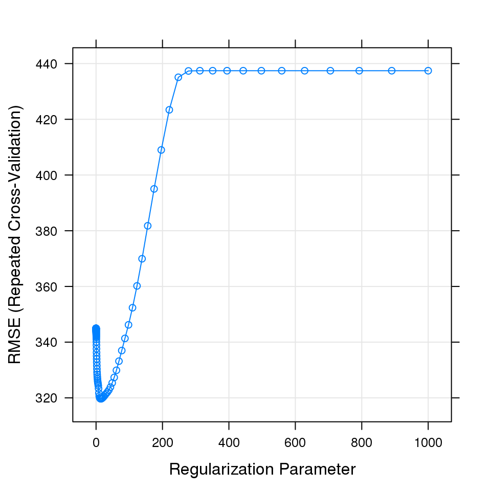

```r
> plot(hit.modelT1)
```

```r
> coef(hit.modelT1$finalModel, hit.model$bestTune$lambda)
```

```
20 x 1 sparse Matrix of class "dgCMatrix"
                        1
(Intercept) -101.08611784
AtBat          .
Hits           2.12682293
HmRun          .
Runs           .
RBI            1.52192252
Walks          2.18699728
Years          .
CAtBat         .
CHits          .
CHmRun         .
CRuns          0.40146625
CRBI           0.06345388
CWalks         .
LeagueN       28.44971454
DivisionW   -109.81369939
PutOuts        0.31513067
Assists        .
Errors         .
NewLeagueN     .
```

```r
> # Test RMSE error
> preds1 <- predict(hit.modelT1, HittersTest)
> TestRMSE2 <- sqrt(mean((HittersTest$Salary - preds1)^2))
> TestRMSE2
```

```
[1] 365.8057
```

Note the test RMSE of the ridge model is 365.7260832 while the test RMSE of the lasso model is 365.8056865. In this scenario, the lasso has an advantage over the ridge model in terms of *parsimony* because 11 of the coefficients in the lasso model are exactly zero.

## 1.5 Dichotomous Response Variable (Logistic Regression)

(Example taken from *An Introduction to Statistical Learning*)

> Goal: Predict whether an individual will default on his or her credit card payment.

```r
> library(ISLR)
> head(Default)
```

```
  default student   balance    income
1      No      No  729.5265 44361.625
2      No     Yes  817.1804 12106.135
3      No      No 1073.5492 31767.139
4      No      No  529.2506 35704.494
5      No      No  785.6559 38463.496
6      No     Yes  919.5885  7491.559
```

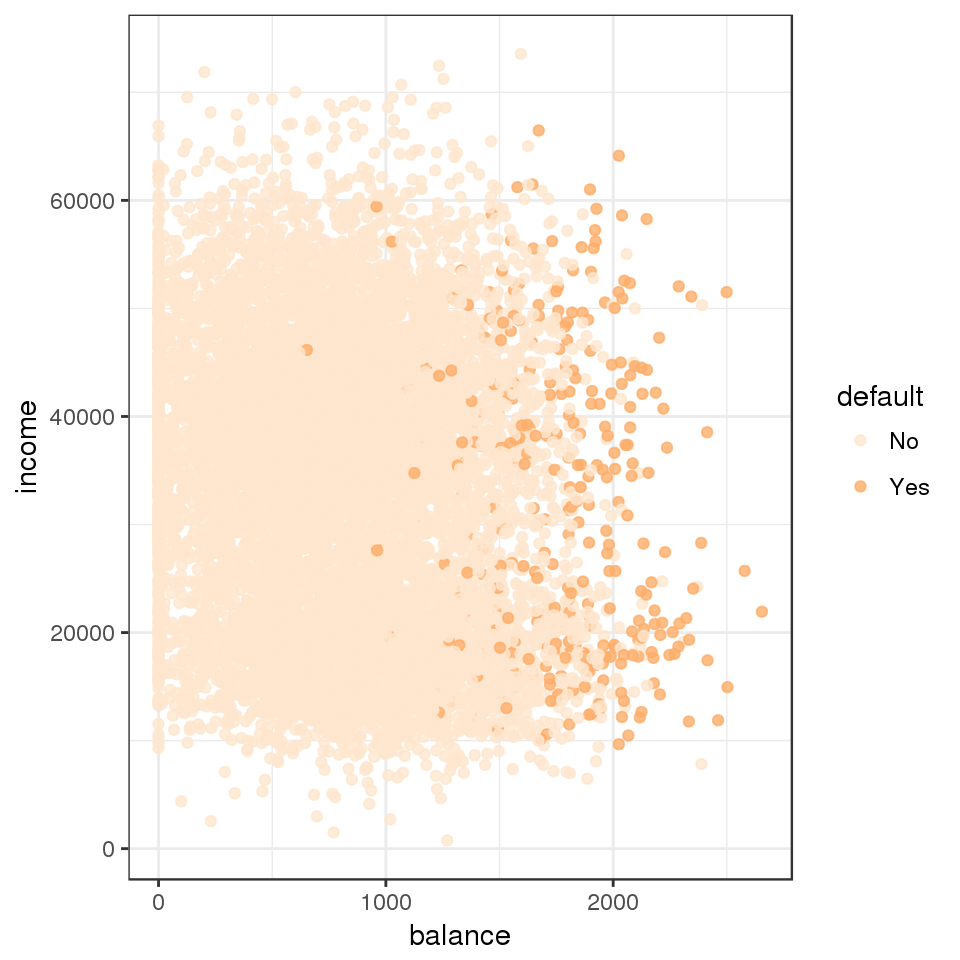

```r
> ggplot(data = Default, aes(x = balance, y = income, colour = default)) +
+   geom_point(alpha = 0.8) +
+   theme_bw() +
+   scale_color_brewer(palette=7)
```

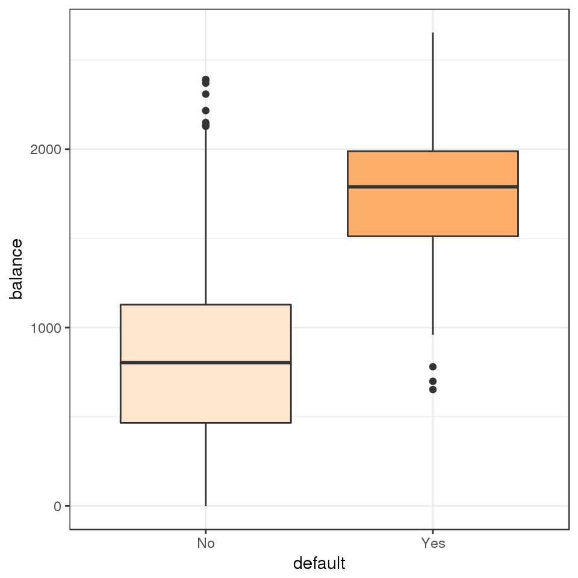

```r
> ggplot(data = Default, aes(x = default, y = balance, fill = default)) +
+   geom_boxplot() +
+   theme_bw() +
+   guides(fill = FALSE) +
+   scale_fill_brewer(palette=7)
```

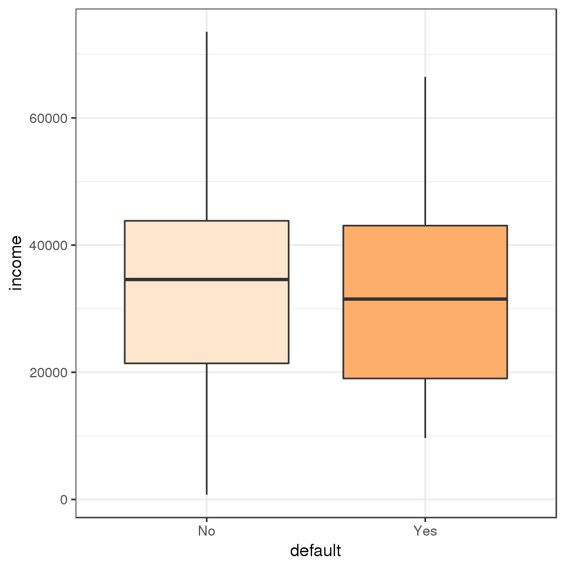

```r
> ggplot(data = Default, aes(x = default, y = income, fill = default)) +
+   geom_boxplot() +
+   theme_bw() +
+   guides(fill = FALSE) +
+   scale_fill_brewer(palette=7)
```

> Why not regression?

```r
> Default$defaultN <- ifelse(Default$default == "No", 0, 1)
> Default$studentN <- ifelse(Default$student =="No", 0, 1)
> summary(Default$defaultN)
```

```
   Min. 1st Qu.  Median    Mean 3rd Qu.    Max.
 0.0000  0.0000  0.0000  0.0333  0.0000  1.0000
```

```r
> head(Default)
```

```
  default student   balance    income defaultN studentN
1      No      No  729.5265 44361.625        0        0
2      No     Yes  817.1804 12106.135        0        1
3      No      No 1073.5492 31767.139        0        0
4      No      No  529.2506 35704.494        0        0
5      No      No  785.6559 38463.496        0        0
6      No     Yes  919.5885  7491.559        0        1
```

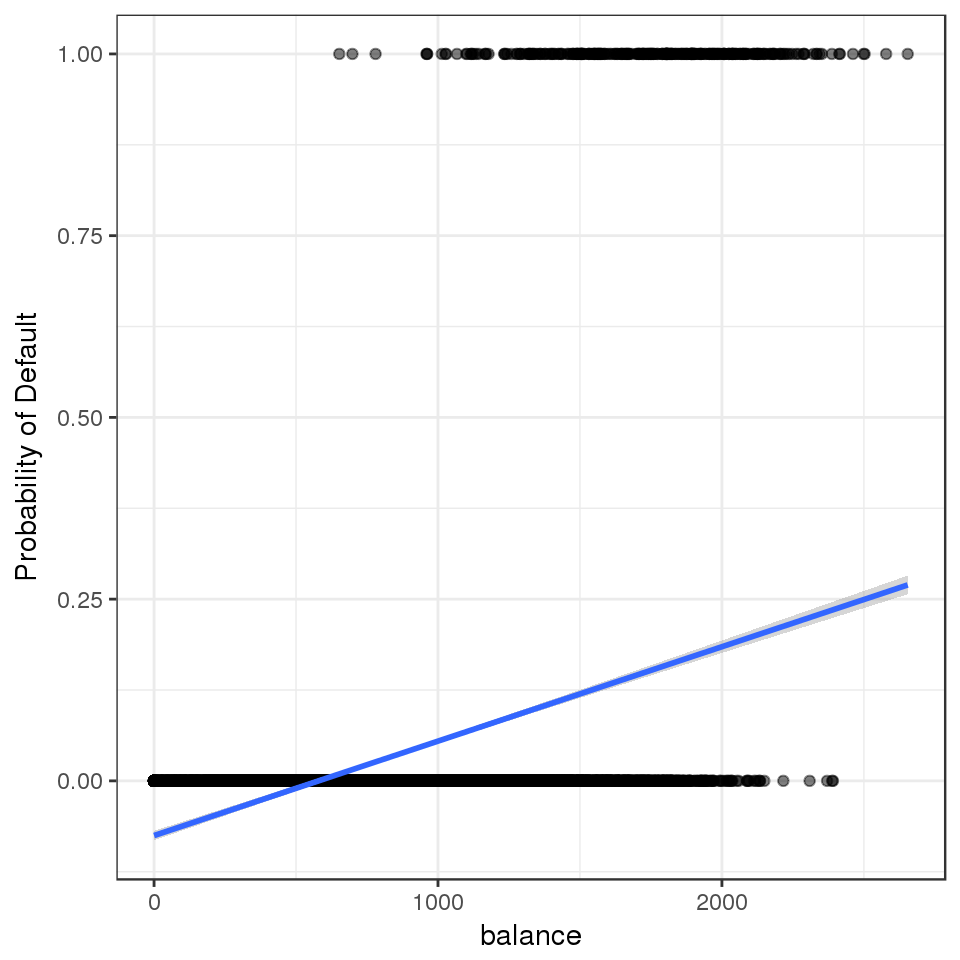

```r
> ggplot(data = Default, aes(x = balance, y = defaultN)) +
+   geom_point(alpha = 0.5) +
+   theme_bw() +
+   stat_smooth(method = "lm") +
+   labs(y = "Probability of Default")
```

## 1.6 Logistic regression

What we need is a function of $X$ that returns values between 0 and 1. Consider the *logistic function*

$$p(X) = \frac{e^{\beta_0 + \beta_1X}}{1 + e^{\beta_0 + \beta_1X}}$$

which will always produce an *S-shaped* curve regardless of the value of $X$.

Let $y = \beta_0 + \beta_1X$, then

$p(X)=\frac{e^y}{1 + e^y} \rightarrow p(X) + e^{y}p(X) = e^{y} \rightarrow p(X) = e^{y} - e^{y}p(X) \rightarrow \frac{p(X)}{1 - p(X)}=e^{y} = e^{\beta_0 + \beta_1X}$

$$\text{log}\left(\frac{p(X)}{1 - p(X)}\right) = \beta_0 + \beta_1X$$

The quantity $\text{log}\left(\frac{p(X)}{1 - p(X)}\right)$ is called the *log-odds* or *logit*, and the quantity $\frac{p(X)}{1 - p(X)}$ is called the odds.

NOTE: In regression, $\beta_1$ gives the average change in $Y$ associated with a one-unit increase in $X$. In a logistic regression model, increasing $X$ by one unit changes the log odds by $\beta_1$, or equivalently it multiplies the odds by $e^{\beta_1}$.

[figure not shown]

```r
> ggplot(data = Default, aes(x = balance, y = defaultN)) +
+   geom_point(alpha = 0.5) +
+   theme_bw() +
+   stat_smooth(method = "glm", family = "binomial") +
+   labs(y = "Probability of Default")
```

The probability of default given `balance` can be written as P(default = Yes | balance).

```r
> log.mod <- glm(default ~ balance, data = Default, family = "binomial")
> summary(log.mod)
```

```
Call:
glm(formula = default ~ balance, family = "binomial", data = Default)

Deviance Residuals:
    Min       1Q   Median       3Q      Max
-2.2697  -0.1465  -0.0589  -0.0221   3.7589

Coefficients:
              Estimate Std. Error z value Pr(>|z|)
(Intercept) -1.065e+01  3.612e-01  -29.49   <2e-16 ***
balance      5.499e-03  2.204e-04   24.95   <2e-16 ***
---
Signif. codes:  0 '***' 0.001 '**' 0.01 '*' 0.05 '.' 0.1 ' ' 1

(Dispersion parameter for binomial family taken to be 1)

    Null deviance: 2920.6  on 9999  degrees of freedom
Residual deviance: 1596.5  on 9998  degrees of freedom
AIC: 1600.5

Number of Fisher Scoring iterations: 8
```

From the output note that $\hat{\beta} = 0.0054989$. This value indicates that an increase in `balance` is associated with an increase in the log odds of `default` by 0.0054989 units.

## 1.7 Making predictions

Using the estimated coefficients, the predicted probability of default for an individual with a balance of $1,500 is

$$\hat{p}(X) = \frac{e^{\hat{\beta_0} + \hat{\beta}_1X}}{1 + e^{\hat{\beta_0} + \hat{\beta_1}X}} = \frac{e^{-10.6513306+ 0.0054989 \times 1500}}{1 + e^{-10.6513306+ 0.0054989 \times 1500}} = 0.0829476.$$

```r
> predict(log.mod, newdata = data.frame(balance = 1500), type = "response")
```

```
         1
0.08294762
```

For an individual with a `balance` of $2,500, the probability of default is

$$p(X) = 0.9567259$$
.

```r
> predict(log.mod, newdata = data.frame(balance = 2500), type = "response")
```

```
        1
0.9567259
```

Are students more likely to default than non-students?

```r
> mod2 <- glm(default ~ student, data = Default, family = "binomial")
> summary(mod2)
```

```
Call:
glm(formula = default ~ student, family = "binomial", data = Default)

Deviance Residuals:
    Min       1Q   Median       3Q      Max
-0.2970  -0.2970  -0.2434  -0.2434   2.6585

Coefficients:
            Estimate Std. Error z value Pr(>|z|)
(Intercept) -3.50413    0.07071  -49.55  < 2e-16 ***
studentYes   0.40489    0.11502    3.52 0.000431 ***
---
Signif. codes:  0 '***' 0.001 '**' 0.01 '*' 0.05 '.' 0.1 ' ' 1

(Dispersion parameter for binomial family taken to be 1)

    Null deviance: 2920.6  on 9999  degrees of freedom
Residual deviance: 2908.7  on 9998  degrees of freedom
AIC: 2912.7

Number of Fisher Scoring iterations: 6
```

Note that the coefficient associated with `studentYes` is positive, and the associated *p-value* is statistically significant. This indicates that students tend to have higher default probabilities than non-students:

$$\widehat{Pr}(\text{default = Yes }|\text{ student = Yes}) = \frac{e^{-3.5041278+ 0.4048871 \times 1}}{1 + e^{-3.5041278+ 0.4048871 \times 1}} = 0.0431386,$$

```r
> predict(mod2, newdata = data.frame(student = "Yes"), type = "response")
```

```
         1
0.04313859
```

$$\widehat{Pr}(\text{default = Yes }|\text{ student = No}) = \frac{e^{-3.5041278+ 0.4048871 \times 0}}{1 + e^{-3.5041278+ 0.4048871 \times 1}} = 0.029195.$$

```r
> predict(mod2, newdata = data.frame(student = "No"), type = "response")
```

```
         1
0.02919501
```

## 1.8 Multiple Logistic Regression

Consider a model that uses `balance`, `income`, and `student` to predict `default`.

```r
> mlog.mod <- glm(default ~ balance + income + student, data = Default, family = "binomial")
> summary(mlog.mod)
```

```
Call:
glm(formula = default ~ balance + income + student, family = "binomial",
    data = Default)

Deviance Residuals:
    Min       1Q   Median       3Q      Max
-2.4691  -0.1418  -0.0557  -0.0203   3.7383

Coefficients:
              Estimate Std. Error z value Pr(>|z|)
(Intercept) -1.087e+01  4.923e-01 -22.080  < 2e-16 ***
balance      5.737e-03  2.319e-04  24.738  < 2e-16 ***
income       3.033e-06  8.203e-06   0.370  0.71152
studentYes  -6.468e-01  2.363e-01  -2.738  0.00619 **
---
Signif. codes:  0 '***' 0.001 '**' 0.01 '*' 0.05 '.' 0.1 ' ' 1

(Dispersion parameter for binomial family taken to be 1)

    Null deviance: 2920.6  on 9999  degrees of freedom
Residual deviance: 1571.5  on 9996  degrees of freedom
AIC: 1579.5

Number of Fisher Scoring iterations: 8
```

There is a surprising result here. The *p-value* associated with `balance` and the `student` are very small, indicating that each of these variables is associated with the probability of `default`. However, the coefficient for `student` is negative, indicating that students are less likely to default than non-students. Yet, the coefficient in `mod2` for `student` was positive. How is it possible for the variable `student` to be associated with an *increase* in probability in `mod2` and a *decrease* in probability in `mlog.mod`?

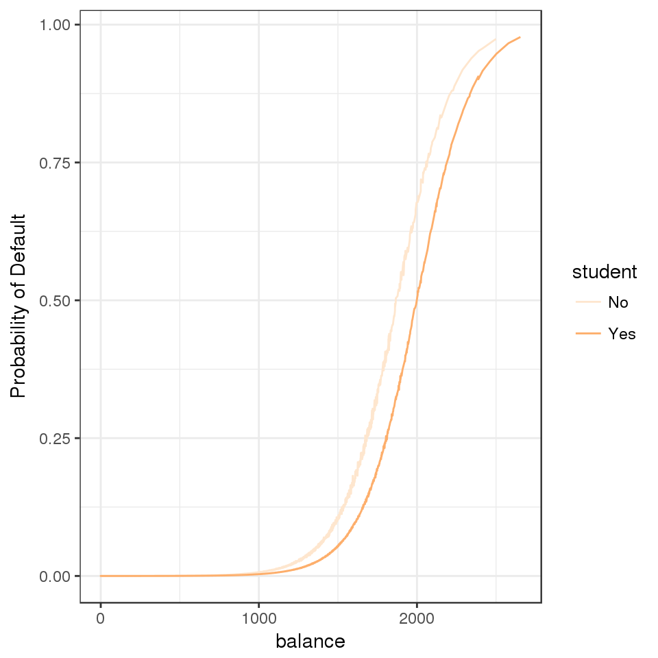

```r
> Default$PrDef <- exp(predict(mlog.mod))/(1 + exp(predict(mlog.mod)))
> # Or the following is the same
> Default$PRdef <- predict(mlog.mod, type = "response")
> ggplot(data = Default, aes(x = balance, y = default, color = student)) +
+   geom_line(aes(x = balance, y = PrDef)) +
+   scale_color_brewer(palette = 7) +
+   theme_bw() +
+   labs(y = "Probability of Default")
```

```r
> library(dplyr)
> Default <- Default %>%
+   arrange(balance) %>%
+   mutate(balanceFAC = cut(balance, breaks = seq(500, 2655, length.out = 10), include.lower = TRUE))
> head(Default)
```

```
  default student balance   income defaultN studentN        PrDef
1      No      No       0 29275.27        0        0 2.080617e-05
2      No     Yes       0 21871.07        0        1 1.065494e-05
3      No      No       0 50265.31        0        0 2.217400e-05
4      No      No       0 49956.58        0        0 2.215325e-05
5      No      No       0 32481.54        0        0 2.100952e-05
6      No      No       0 43658.23        0        0 2.173402e-05
         PRdef balanceFAC
1 2.080617e-05       <NA>
2 1.065494e-05       <NA>
3 2.217400e-05       <NA>
4 2.215325e-05       <NA>
5 2.100952e-05       <NA>
6 2.173402e-05       <NA>
```

```r
> T1 <- xtabs(~balanceFAC + default, data = Default, subset = student == "Yes")
> T2 <- xtabs(~balanceFAC + default, data = Default, subset = student == "No")
> SDR  <- T1[, 2]/apply(T1[, 1:2], 1, sum)
> NSDR <- T2[, 2]/apply(T2[, 1:2], 1, sum)
> BalanceM <- c(500+120, 739+120, 979+120, 1220+120, 1460+120, 1700+120, 1940+120, 2180+120, 2420+120)
> DF <- data.frame(SDR, NSDR, BalanceM)
> DF
```

```
                            SDR        NSDR BalanceM
(500,739]           0.000000000 0.001571092      620
(739,979]           0.000000000 0.003007519      859
(979,1.22e+03]      0.005454545 0.012252592     1099
(1.22e+03,1.46e+03] 0.025000000 0.043923865     1340
(1.46e+03,1.7e+03]  0.085365854 0.140056022     1580
(1.7e+03,1.94e+03]  0.248407643 0.394736842     1820
(1.94e+03,2.18e+03] 0.553571429 0.760000000     2060
(2.18e+03,2.42e+03] 0.818181818 0.888888889     2300
(2.42e+03,2.66e+03] 1.000000000 1.000000000     2540
```

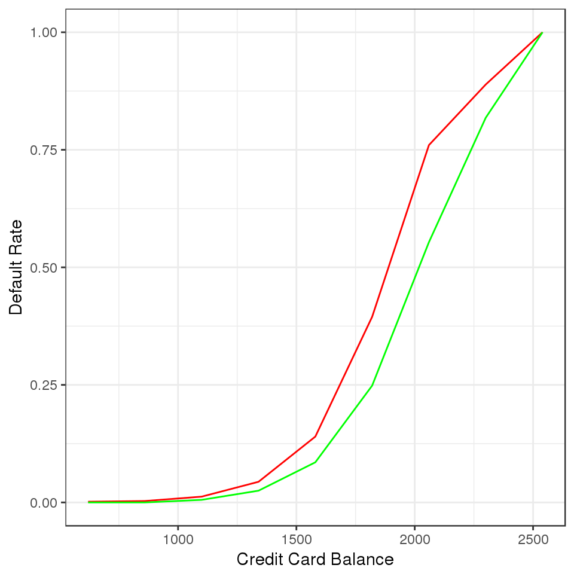

```r
> ggplot(data = DF, aes(x = BalanceM, y = NSDR)) +
+   geom_line(color = "red") +
+   geom_line(aes(x = BalanceM, y = SDR), color = "green") +
+   theme_bw() +
+   labs(y = "Default Rate", x = "Credit Card Balance")
```

## 1.9 Odds Ratio (OR)

The *odds ratio*, denoted OR, is the ratio of the odds for $X = 1$ to the odds for $X = 0$, and is given by the equation

$$\text{OR}=\frac{\frac{p(1)}{1 - p(1)}}{\frac{p(0)}{1 - p(0)}}.$$

Substituting
$$\frac{e^{\beta_0 + \beta_1}}{1 + e^{\beta_0 + \beta_1}}$$
for $p(X=1)$, and
$$\frac{e^{\beta_0}}{1 + e^{\beta_0}}$$
for $p(X=0)$, respectively, one can show that
$$\text{OR} = e^{\beta_1}.$$

The odds ratio is widely used as a measure of association as it approximates how much more likely or unlikely (in terms of odds) it is for the outcome to be present among those subjects with $X = 1$ as compared to those subjects with $X = 0$.

Using the `mlog.mod` model, the response variable $Y$ is `default`, which denotes whether a credit card holder has defaulted (Yes/1) or not defaulted (No/0) on his/her current payment. The independent variable $X$ is `student`, which denotes whether the individual is a student (Yes/1) or is not a student (No/1). A hypothetical odds ratio in this scenario of 2 is interpreted to mean that the odds of default among students is two times greater than the odds of default among non-students.

An estimate of the odds ratio is

$$\widehat{\text{OR}} = e^{-0.6467758} = 0.5237317.$$

This is interpreted to mean that the odds of default among students is 0.5237317 the odds of default among non-students.